# Assignment-5_1

Alexandre Miranda Bastos

12 de outubro de 2016

## Question 1

- Code for reading in the dataset and/or processing the data

I´ve downloaded the data outside the R code and unzip it berofe use in the Assignment. For reading the dataset I use the function **read.csv()**, with the args activity.csv(the file to load), header=TRUE, sep=“,”). To transform the date data into a date attribute (to perform calculations) I use the **transform** function with the args Topic5_As1 as the data table to be transformed, and the conversion of date attribute to a date variable.

```r
knitr::opts_chunk$set(echo = TRUE)
# To import the data from the file "activity.csv"
Topic5_As1 = read.csv("activity.csv", header=TRUE, sep=",")
# transforming the date data from text to date format
Topic1_As1_DtTransf = transform(Topic5_As1, date = as.Date(date, format="%Y-%m-%d"))
head(Topic1_As1_DtTransf)
```

```
##   steps       date interval
## 1    NA 2012-10-01        0
## 2    NA 2012-10-01        5
## 3    NA 2012-10-01       10
## 4    NA 2012-10-01       15
## 5    NA 2012-10-01       20
## 6    NA 2012-10-01       25
```

## Question 2

- Histogram of the total number of steps taken each day

In that item I count the number of steps by day using the function **aggregate** to realize the sum of the counts of all records. And plot the histogram in the data generated.

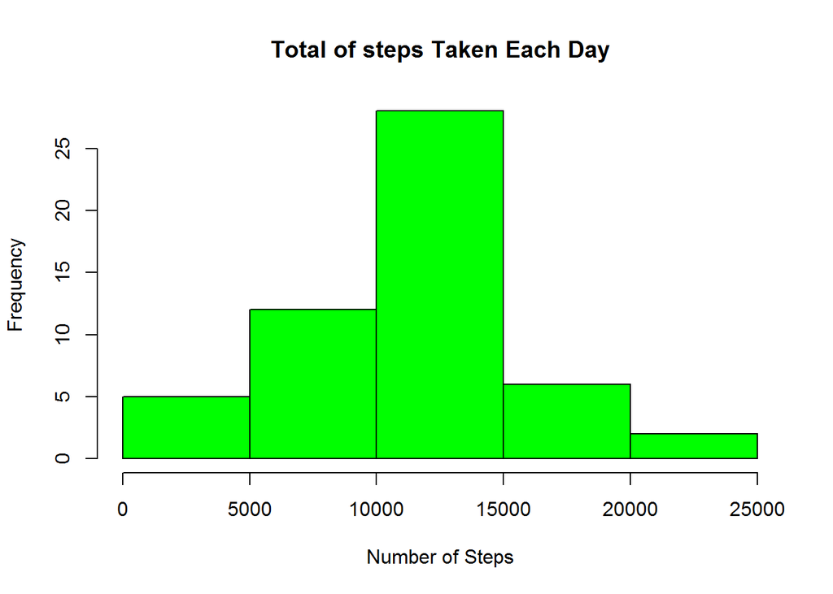

```r
knitr::opts_chunk$set(echo = TRUE)
# Sum the steps by day using the TOPIC_As1_DtTransf variable
SUM_STEPS_DAY = aggregate(steps ~ date, FUN = sum, data = Topic1_As1_DtTransf)
# Ploting the Histogram with the total fo steps taken each day
hist(SUM_STEPS_DAY$steps, xlab="Number of Steps", main="Total of steps Taken Each Day",col="green")
```

## Question 3

- Mean and median number of steps taken each day

In that item I only calculate the mean and median for the variable

```r
knitr::opts_chunk$set(echo = TRUE)
# Mean of SUM_STEPS_DAY$steps
MEAN_STEPS = mean(SUM_STEPS_DAY$steps)
print(MEAN_STEPS)
```

```
## [1] 10766.19
```

```r
knitr::opts_chunk$set(echo = TRUE)
# Median of SUM_STEPS_DAY$steps
MEDIAN_STEPS = median(SUM_STEPS_DAY$steps)
print(MEDIAN_STEPS)
```

```
## [1] 10765
```

## Question 4

- Time series plot of the average number of steps taken

In that item we use the **aggregate** function again to generate the means of the steps in function of its intervals.

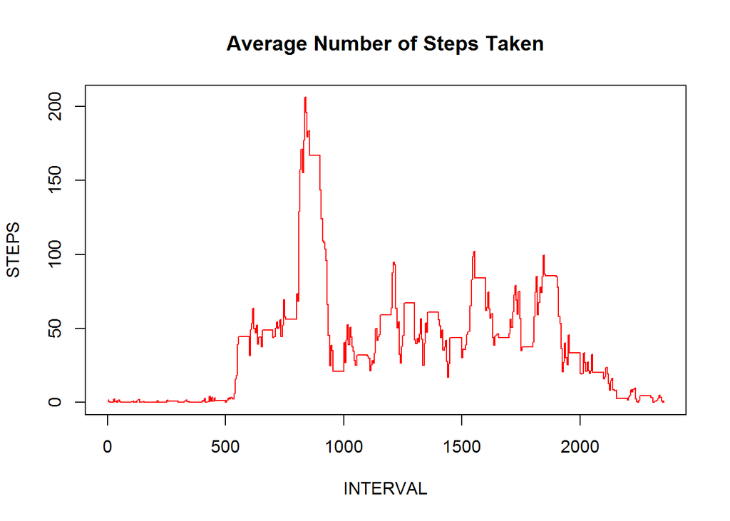

```r
knitr::opts_chunk$set(echo = TRUE)
# Generating the data
MEAN_STEPS_INTERV = aggregate(steps ~ interval, FUN=mean, data=Topic1_As1_DtTransf)
#ploting the result
plot(x=MEAN_STEPS_INTERV$interval, y=MEAN_STEPS_INTERV$steps, type="s", main="Average Number of Steps Taken", xlab="INTERVAL", ylab="STEPS", col = "red")
```

## Question 5

- The 5-minute interval that, on average, contains the maximum number of steps

In that question we ordered the variable generate in the last question and get the first line, that is tue answer for the question.

```r
knitr::opts_chunk$set(echo = TRUE)
#Order the variable to find the highest value
ORDER_AVER = MEAN_STEPS_INTERV[order(-MEAN_STEPS_INTERV$steps),]
print(ORDER_AVER[1, ])
```

```
##     interval    steps
## 104      835 206.1698
```

## Question 6

- Code to describe and show a strategy for imputing missing data

In that question we use the strategy of calculate the mean per 5-minute interval and then create a new dataset that is equal to the original but with the missing data filled in.

```r
knitr::opts_chunk$set(echo = TRUE)
# Aggeregating the steps by interval and calculating its mean
MEAN_INTERV = aggregate(steps ~ interval, FUN=mean, data=Topic1_As1_DtTransf)
# Using Interval to merge the two datasets
MERGE_Topic1_As1 = merge(x=Topic1_As1_DtTransf, y=MEAN_INTERV, by="interval")
# Use the interval mean to fill in the column steps
MERGE_Topic1_As1$steps <- ifelse(is.na(MERGE_Topic1_As1$steps.x), MERGE_Topic1_As1$steps.y, MERGE_Topic1_As1$steps.x)
# Creating a subset only with the columns steps, date and interval to use on the next step
Sst_SDI = MERGE_Topic1_As1[c("steps", "date", "interval")]
head(Sst_SDI)
```

```
##      steps       date interval
## 1 1.716981 2012-10-01        0
## 2 0.000000 2012-11-23        0
## 3 0.000000 2012-10-28        0
## 4 0.000000 2012-11-06        0
## 5 0.000000 2012-11-24        0
## 6 0.000000 2012-11-15        0
```

## Question 7

- Histogram of the total number of steps taken each day after missing values are imputed

Updating the Histogram to represent the data when the missing values are imputed with the new value.

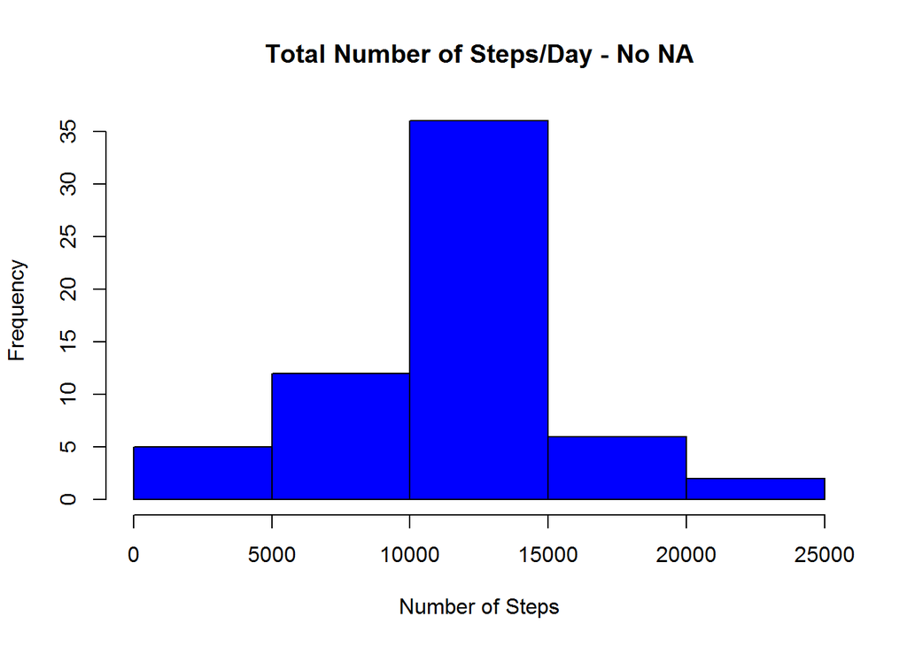

```r
knitr::opts_chunk$set(echo = TRUE)
# aggregate by date and calculate sum
SUBS_NA_NewData = aggregate(steps ~ date, FUN=sum, data=Sst_SDI)
# Plotting new Data Histogram
hist(SUBS_NA_NewData$steps, xlab="Number of Steps", main="Total Number of Steps/Day - No NA",col="blue")
```

## Question 8

- Panel plot comparing the average number of steps taken per 5-minute interval across weekdays and weekends

To answer this question a new variable is necessary. I create it in the “Sst_SDI” variable to distinguish betwen a weekend day or weekdays. Then I create a plot for comparing the category.To better inplement this graphs, I load de lattice library for better visualization.

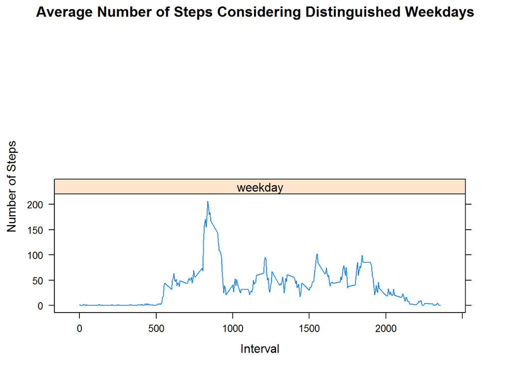

```r
knitr::opts_chunk$set(echo = TRUE)
# create new variable to distinguish from weekend to weekday filling the # new column with weekend value if it is saturday or ssunday or weekday in the other side
Sst_SDI$weekdays = as.factor(ifelse(weekdays(Sst_SDI$date, abbreviate = FALSE) %in% c("Saturday", "Sunday"), "weekend", "weekday"))

# loading lattice package to use the plot function xyplot
library(lattice)
# Using weekday to aggregating the data and using function mean
Sst_SDI_Wkday <- aggregate(steps ~ weekdays + interval, FUN=mean, data=Sst_SDI)

# Generating the plot to campare the two class of days
xyplot(steps ~ interval | weekdays, Sst_SDI_Wkday, type = "l", xlab = "Interval", ylab = "Number of Steps", main = "Average Number of Steps Considering Distinguished Weekdays", layout = c(1, 2))
```

**OBS: Instead of searcching for the error occurring in this last exercise I did not find. The function to distinguish from a Weekday to a weekend day doesn´t work good, generating only “weekday” value.**